# ingressWeb

Sigbert Ingress

2018-03-05

## Creating artificial portal positions

### Random positions

`random2` creates `n` portal positions. The last three portals form a outer triangle which consists all other portals.

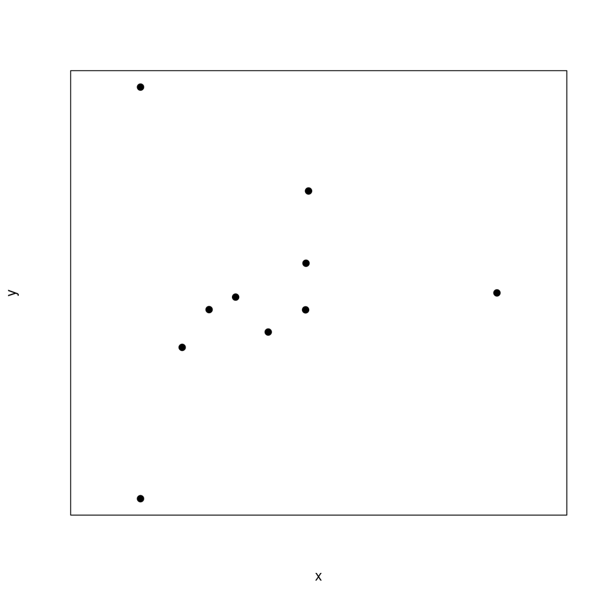

```r
set.seed(0)
library(ingressWeb)
web <- ingressWeb(random2(10))
plot(web)
```

The positions are generated from univariate random functions which are called twice. The parameter `d` is multiplicator which determines the distance of the outer portals. If `d` is smaller than `1` then the three other portals might not be outer portals anymore.

The parameter `random` is the univariate random generator function, the default is `rnorm`. The `...` may contain further parameters for the random generator function. As default the random portal positions are generated from an independent bivariate standard normal distribution.

The following code generates the portal positions from an independent bivariate uniform distribution.

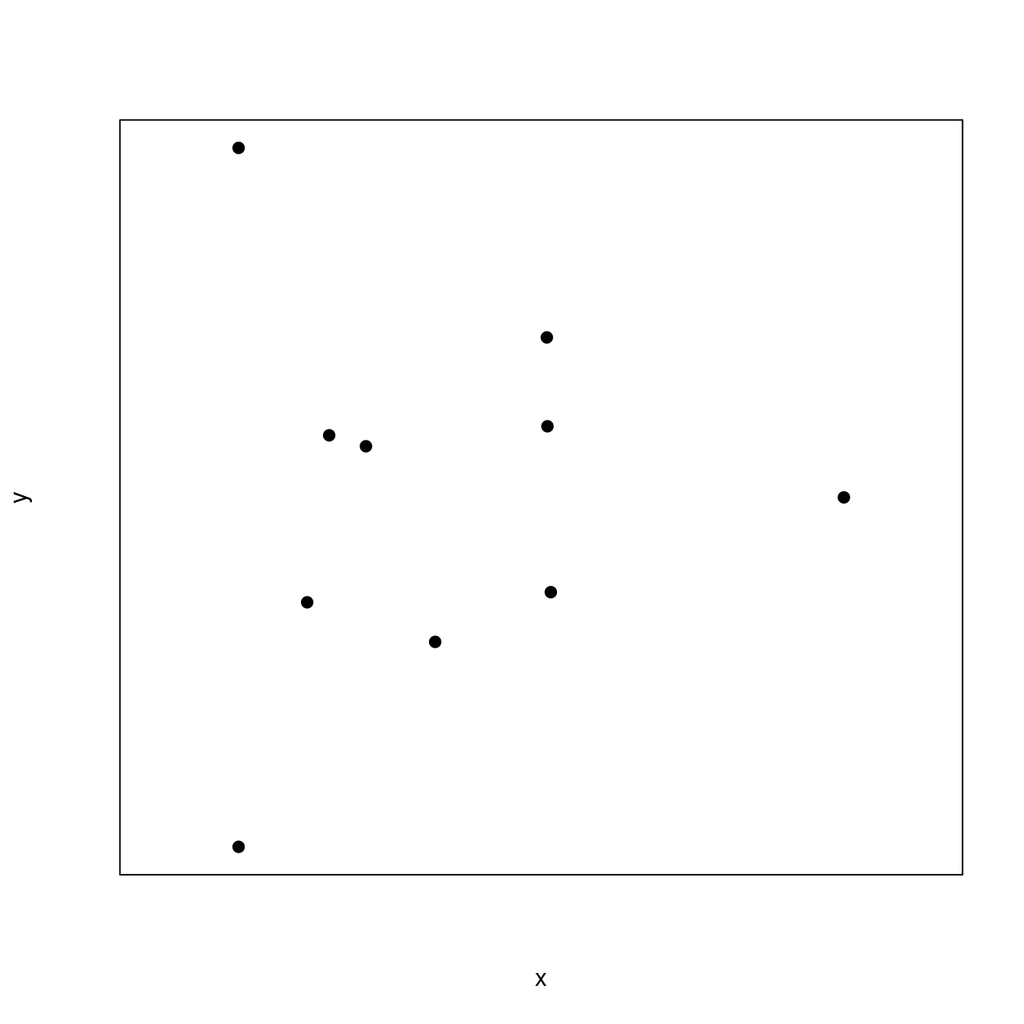

```r
set.seed(0)
library(ingressWeb)
web <- ingressWeb(random2(10, random=runif))
plot(web)
```

### Cobweb

`cobweb` creates `n` portal positions for each leg of a Cobweb.

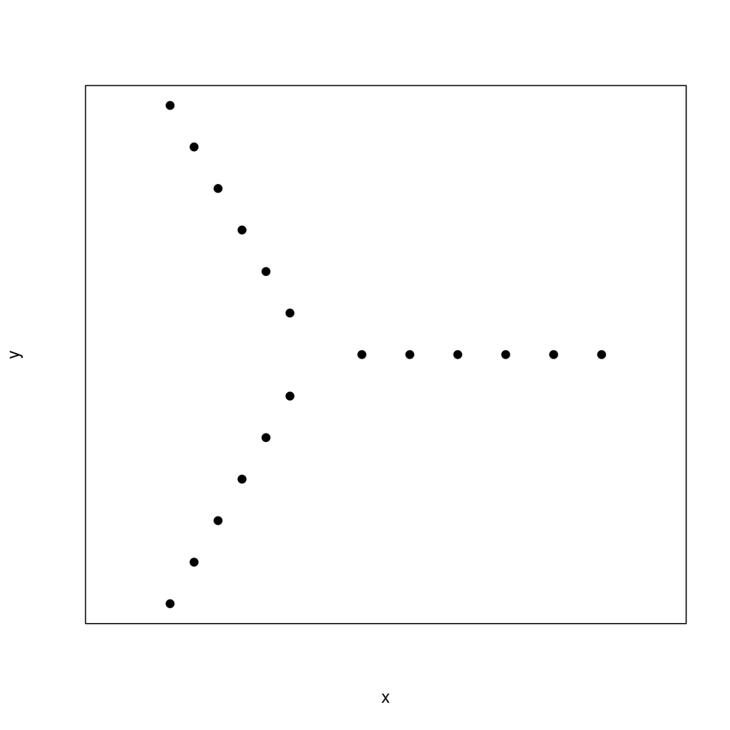

```r
set.seed(0)
library(ingressWeb)
web <- ingressWeb(cobweb(6))
plot(web)
```

The parameter `d` distorts each position by a uniform number in the interval `[-d;d]`. In the real world you will not get such nice portal positions for a cobweb.

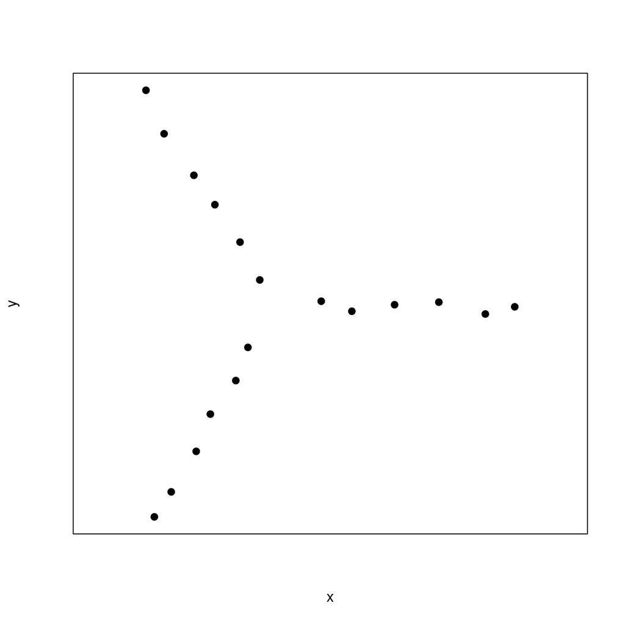

```r
set.seed(0)
library(ingressWeb)
web <- ingressWeb(cobweb(6, d=0.2))
plot(web)
```

### Herring/Fish bone

`fishbone` creates `n` portal positions for a fish bone web.

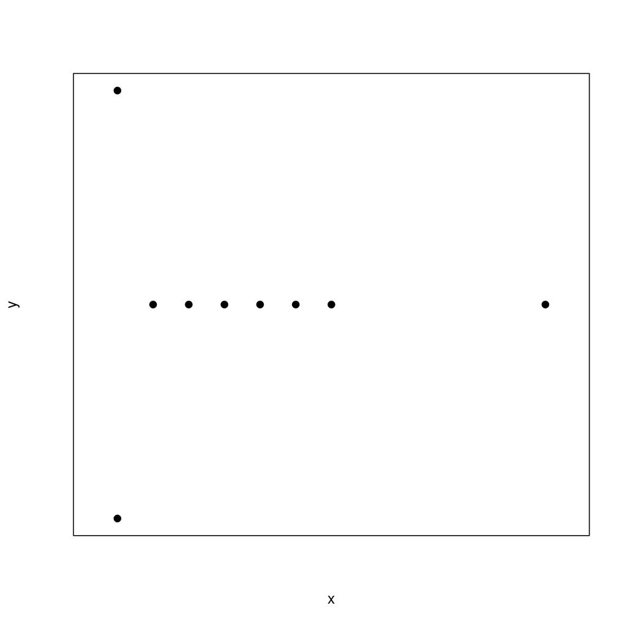

```r
set.seed(0)
library(ingressWeb)
web <- ingressWeb(fishbone(9))
plot(web)
```

The parameter `d` distorts each position by a uniform number in the interval `[-d;d]`. In the real world you will not get such nice portal positions for fish bone web.

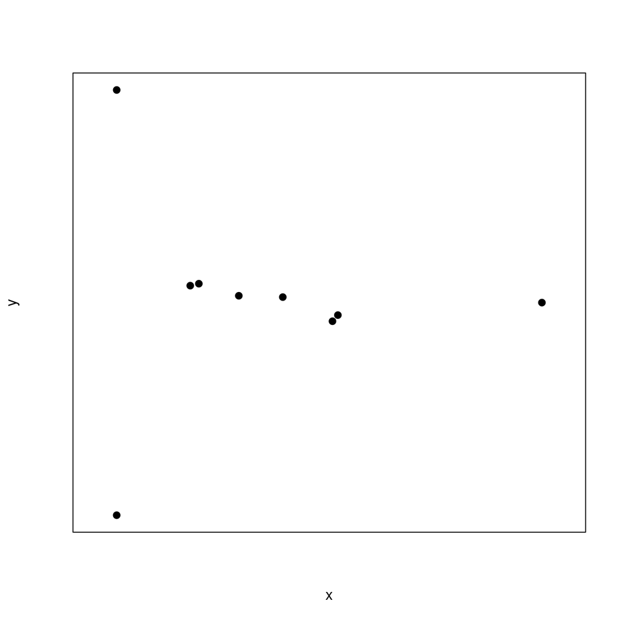

```r
set.seed(0)
library(ingressWeb)
web <- ingressWeb(fishbone(9, d=0.2))
plot(web)
```

## Creating a full web

Once a web with portal positions has been created it is necessary to link the portals after some specific link plan. `make.links` creates links following some link plan. Except for the MaxArea plan, the default, it necessary to give a named parameter which also tells which link plan has to followed.

### MaxArea web

The MaxArea web maximizes the mind units (MU) you receive. The MUs are proportional to the area a field covers. Therefore the algorithm tries to maximize the area covered by the fields.

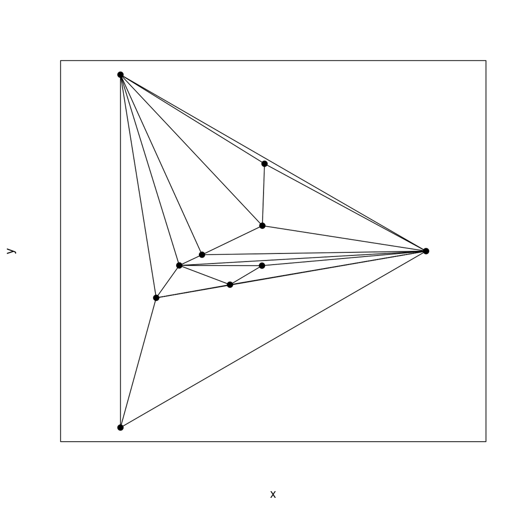

```r
set.seed(0)
library(ingressWeb)
web <- ingressWeb(random2(10))
fullweb <- make.links(web)
plot(fullweb)
```

### Cobweb

For the Cobweb use

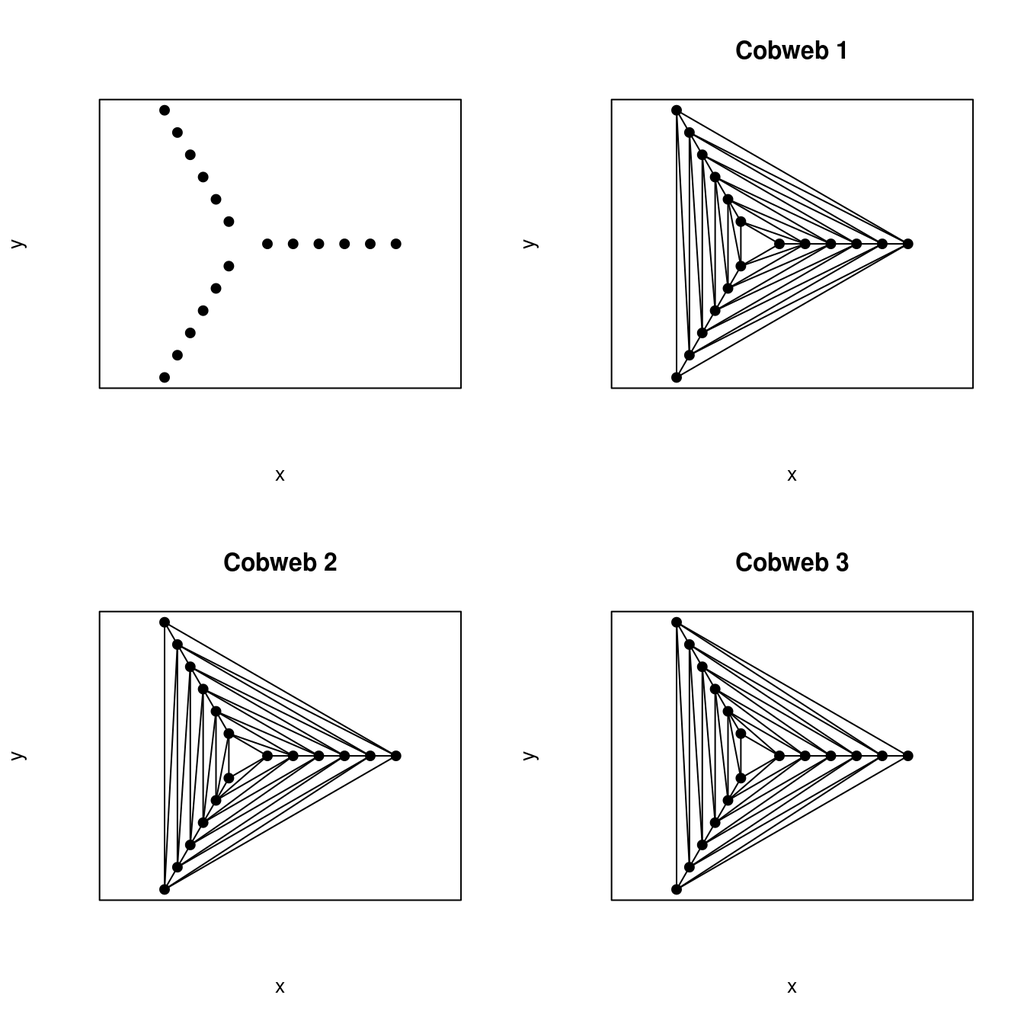

```r
set.seed(0)
library(ingressWeb)
web <- ingressWeb(cobweb(6))
web1 <- make.links(web, cobweb=1)
web2 <- make.links(web, cobweb=2)
web3 <- make.links(web, cobweb=3)
par(mfrow=c(2,2))
plot(web)
plot(web1, main="Cobweb 1")
plot(web2, main="Cobweb 2")
plot(web3, main="Cobweb 3")
```

The `cobweb` parameter determines at which outer portal the algorithm starts. At a first glance the cob webs look very similar, but in fact the linking structure is different.

### Herring/Fish bone web

For the fish bone use

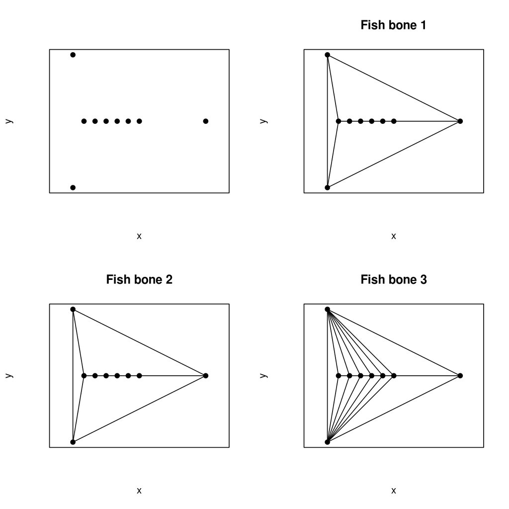

```r
set.seed(0)
library(ingressWeb)
web <- ingressWeb(fishbone(9))
web1 <- make.links(web, fishbone=1)
web2 <- make.links(web, fishbone=2)
web3 <- make.links(web, fishbone=3)
par(mfrow=c(2,2))
plot(web)
plot(web1, main="Fish bone 1")
plot(web2, main="Fish bone 2")
plot(web3, main="Fish bone 3")
```

Note that you have to choose the “right” value for the parameter `fishbone` to create a fish bone web.

### Fanfield web

For the Fanfield use

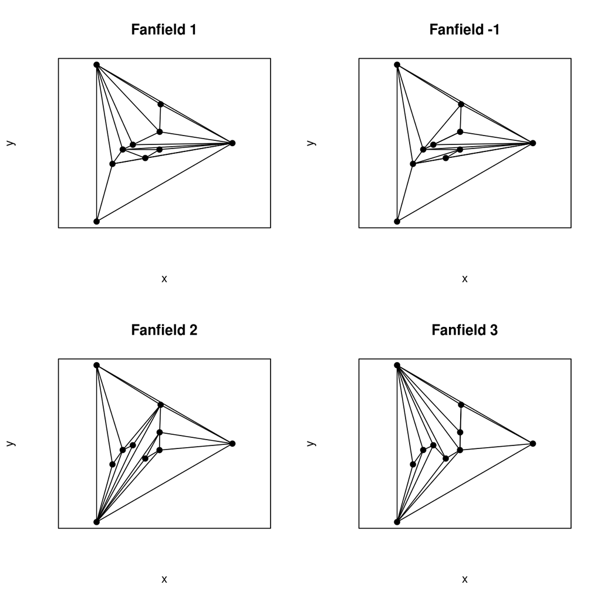

```r
set.seed(0)
library(ingressWeb)
web <- ingressWeb(random2(10))
web1 <- make.links(web, fanfield=1)
web2 <- make.links(web, fanfield=-1)
web3 <- make.links(web, fanfield=2)
web4 <- make.links(web, fanfield=3)
par(mfrow=c(2,2))
plot(web1, main="Fanfield 1")
plot(web2, main="Fanfield -1")
plot(web3, main="Fanfield 2")
plot(web4, main="Fanfield 3")
```

The `fanfield` parameter determines which outer portal is the anchor. The parameter can have positive or negative values, it determines the counting order of the portal (clockwise or anti-clockwise).

### Delaunay web

For the Delaunay web use

```r
set.seed(0)
library(ingressWeb)
web <- ingressWeb(random2(10))
web1 <- make.links(web, delaunay=TRUE)
```

```
##
##      PLEASE NOTE:  As of version 0.3-5, no degenerate (zero area)
##      regions are returned with the "Qt" option since the R
##      code removes them from the triangulation.
##      See help("delaunayn").
```

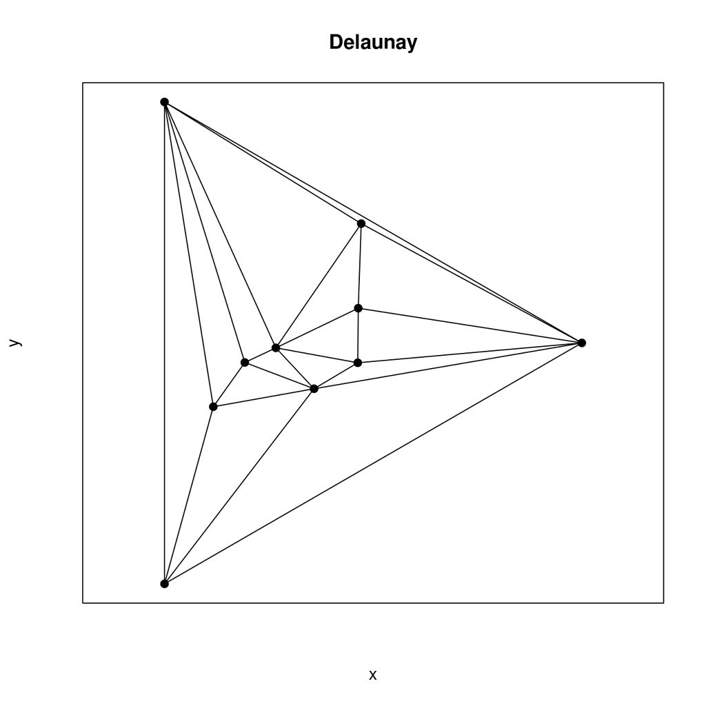

```r
plot(web1, main="Delaunay")
```

The Delaunay web contains usually only one multilayer.

## Query a web

### Overview

You can query each a web for different informations: portals, links, fields, area of field (mind units). `summary` summarizes this information.

```r
set.seed(0)
library(ingressWeb)
web <- ingressWeb(random2(10))
summary(web)
```

```
##   portals     links min_field max_field    min_mu    max_mu
##        10         0         0         0         0         0
```

```r
web2 <- make.links(web)
summary(web2)
```

```
##   portals     links min_field max_field    min_mu    max_mu
##        10        24        15        22        38       141
```

### Specific queries

Functions are available for detailled information:

- `portals`,
- `links`,
- `fields` and
- `mindunits`.

```r
set.seed(0)
library(ingressWeb)
web  <- ingressWeb(random2(10))
web2 <- make.links(web)
portals(web2)
```

```
## [1] 10
```

```r
links(web2)          # total number of links
```

```
## [1] 24
```

```r
l<-links(web2, TRUE) # number of links per portal
table(l)
```

```
## l
## 3 4 5 6 7 9
## 3 3 1 1 1 1
```

```r
fields(web2)         # with multilayers
```

```
## min_field max_field
##        15        22
```

```r
mindunits(web2)      # not rounded up
```

```
##    min_mu    max_mu
##  37.84231 140.50308
```